# Classifying NQS Rating Tiers for Australian Education and Care Services

G02

# Introduction

Australian education and care services are assessed against the National Quality Standard (NQS). This project examines whether administrative characteristics available in the national registers contain useful information for classifying a service’s recorded quality tier.

# Framing & Dataset Selection

## Research Question

To what extent can service type, service scale, operating patterns, geographic location, and provider characteristics be used to classify an Australian education and care service’s recorded NQS rating tier as Below NQS, Meeting NQS, or Above NQS?

## Unit of Analysis and Outcome

Each observation represents one approved Australian education and care service, uniquely identified by its `ServiceApprovalNumber`. The services register contains 18,183 unique services.

The outcome is a three-level categorical variable derived from `OverallRating`. Significant Improvement Required and Working Towards NQS are grouped as Below NQS; Meeting NQS remains unchanged; and Exceeding NQS and Excellent are grouped as Above NQS. This grouping follows the ordering of the official NQS rating levels and avoids retaining two extremely small classes (https://www.acecqa.gov.au/assessment/assessment-and-rating-process).

Among services with a recorded rating, 1264 are Below NQS, 12,748 are Meeting NQS, and 3,148 are Above NQS. A further 1,023 services have no recorded rating and are excluded from the labelled classification data.

## Predictors, Stakeholders and Significance

Candidate predictors include service type, number of approved places, operating schedules, state, service age, provider age, and provider scale. Current and previous rating information will be excluded from the predictors to prevent target leakage.

The main stakeholders are education and care regulatory authorities, service providers, and policy researchers. The analysis will assess whether observable service and provider characteristics contain useful information for distinguishing recorded NQS rating tiers. It examines predictive associations and does not replace the formal assessment and rating process.

# Consider & Gather Data

## Data Sources and Snapshot

The Australian Children’s Education & Care Quality Authority (ACECQA) publishes national registers of approved education and care services and approved providers. The registers are sourced from the National Quality Agenda IT System and updated daily. The two CSV files used here were downloaded on 18 September 2026:

- `Education-services-au-export.csv`
- `Approved-providers-au-export.csv`

The services register contains service characteristics, operating schedules, seven Quality Area ratings, and the recorded overall rating. The providers register contains provider identity, location, approval date, trading name, and approval conditions. The official source is https://www.acecqa.gov.au/resources/national-registers.

```r
knitr::kable(
  source_dimensions,
  col.names = c("Dataset", "Rows", "Columns"),
  caption = "Dimensions of the source and analysis datasets"
)
```

Dimensions of the source and analysis datasets

| Dataset | Rows | Columns |
| --- | --- | --- |
| Education services register | 18183 | 98 |
| Approved providers register | 10095 | 10 |
| Integrated labelled analysis data | 17160 | 31 |

## Data Linkage and Derived Variables

The services register is the primary table. It was linked to the providers register using `Provider Approval Number`, a many-services-to-one-provider relationship. The `Service Approval Number` field in the provider export was entirely empty and was therefore not used. Both retained identifiers were unique at their expected unit of analysis: there were no duplicate `ServiceApprovalNumber` values in the services register and no duplicate provider approval numbers in the providers register. All 18,183 service rows matched a provider record.

Provider scale was derived as the number of registered services linked to each provider. Service and provider ages were calculated from their approval dates using the fixed snapshot date. Operating start and end times were converted into open-day and weekly-hour summaries for annual, school-term, and holiday schedules. Identifiers remain in the processed file for audit and linkage but will not be predictors.

```r
knitr::kable(
  linkage_summary,
  col.names = c("Linkage check", "Value"),
  caption = "Data linkage validation"
)
```

Data linkage validation

| Linkage check | Value |
| --- | --- |
| Service rows | 18183 |
| Unique service IDs | 18183 |
| Provider rows | 10095 |
| Unique provider IDs in provider register | 10095 |
| Unique provider IDs represented by services | 7209 |
| Service rows unmatched to provider register | 0 |
| Labelled analysis rows | 17160 |

## Outcome Definition and Leakage Control

```r
services_base %>%
  count(rating_tier, .drop = FALSE) %>%
  mutate(percent = round(100 * n / sum(n), 1))
```

```
## # A tibble: 4 × 3
##   rating_tier     n percent
##   <fct>       <int>   <dbl>
## 1 Below NQS    1264     7
## 2 Meeting NQS 12748    70.1
## 3 Above NQS    3148    17.3
## 4 <NA>         1023     5.6
```

The outcome consolidates the five recorded NQS levels into three ordered tiers: Significant Improvement Required and Working Towards NQS become **Below NQS**; Meeting NQS remains **Meeting NQS**; and Exceeding NQS and Excellent become **Above NQS**. This retains the policy ordering while avoiding two classes with only four and 25 observations.

Current Quality Area 1–7 ratings and all current or previous overall-rating fields are excluded from the modelling data. The official overall rating is directly determined from the Quality Area ratings, so including them would reveal the outcome rather than test whether service and provider characteristics are informative.

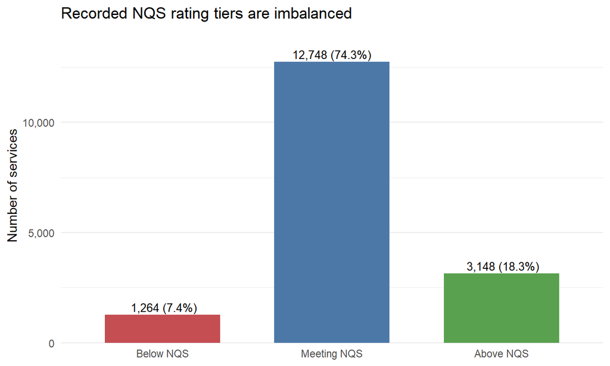

```r
rating_tier_plot
```

The outcome is imbalanced: Meeting NQS represents 74.3% of labelled services, compared with 7.4% Below NQS and 18.3% Above NQS. A stratified split and imbalance-aware evaluation metrics are therefore required.

## Dataset Requirement Justification

The dataset satisfies four assignment criteria:

1. **Large:** The services register contains 18,183 observations, exceeding the 10,000-row threshold. The approximately 15 MB source file is manageable in R, although a single scripted preparation step is used to avoid repeating joins and time conversions.
2. **Messy:** There are 1,023 missing outcomes and 356 missing approved-place values. Schedule fields contain substantial structural missingness because different service types use different operating schedules. Provider trading names and approval conditions are also incomplete. Provider scale is strongly right-skewed, ranging from one to 611 linked services, and requires further outlier assessment.
3. **Integrated:** Two official registers are linked by `Provider Approval Number`. The linkage is validated for uniqueness and completeness, and provider-level age and scale are added to each service record.
4. **Multi-class:** The original outcome has five rating levels. The modelling outcome has three ordered classes with marked imbalance, as shown above.

Although the linked raw data exceeds 100 columns, the project does not rely on the **Complex** criterion because duplicated administrative fields and leakage-prone rating fields must be removed before modelling.

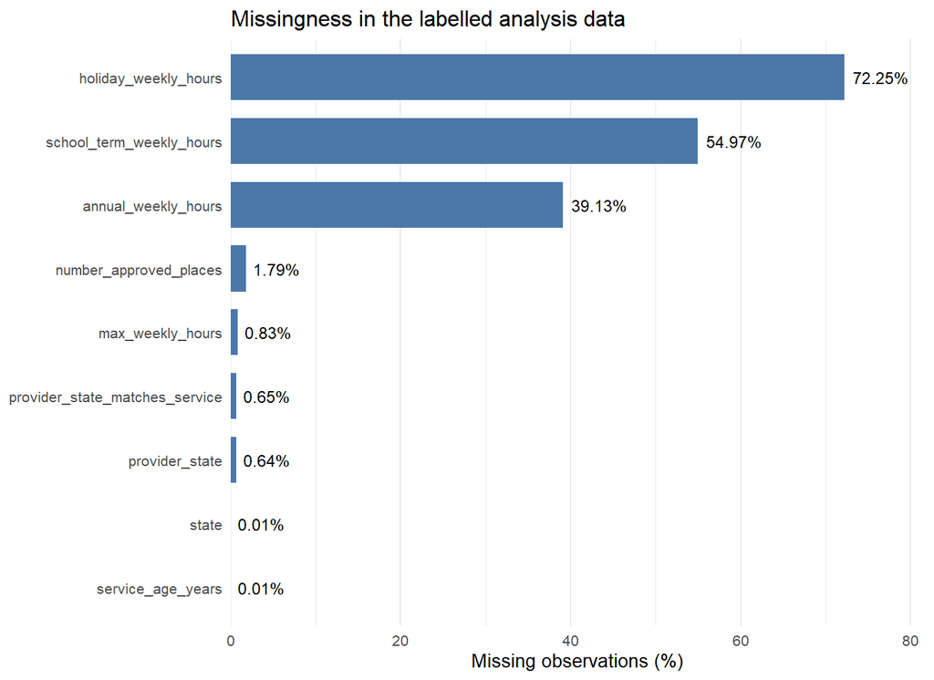

```r
missingness_plot
```

Missing operating-pattern values are not automatically equivalent to data errors: some are structurally absent because a service does not use that schedule type. The preprocessing plan should therefore preserve explicit schedule-type indicators and distinguish structural absence from genuinely missing values. Numeric missing values will require imputation within resampling, rather than before the train/test split.

## Final Analysis Variables

The processed labelled dataset contains 17160 services and 31 variables, including two audit identifiers and the outcome. The remaining fields cover service type and scale, location, service offerings, operating patterns, provider age, and provider scale. A complete variable dictionary is generated as `data/processed/acecqa_variable_dictionary.csv`.

# Exploratory Data Analysis (EDA)

## Categorical Variables

**Univariate Plot**

Examining the distributions of categorical variables of registered services displays some potential issues with imbalanced variables:

1. Highly Imbalanced: `temporarily_closed` (100% No), `service_type` (98% Centre-Based Care), `other_service` (96% No), `provider_has_conditions` (96% False), `preschool_part_school` (95% No). The variables have little to no variation and rare levels will likely produce unstable estimates.
2. Imbalanced: `provider_state` and `state` both shows that most of the registered services are located in NSW, VIC, QLD. Trained model might under-perform for new observations with `state` and `provider_state` with values outside of those three states.

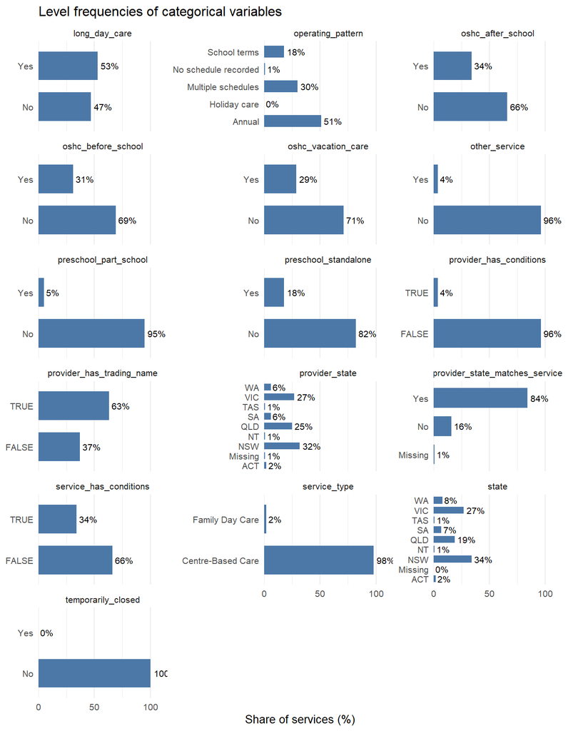

```r
categorical_univariate_plot
```

**Rating Tier vs. Categorical Predictor**

Computing Cramer’s V for each predictor to the target variable, the following variables showed strongest association: `preschool_standalone` (V=0.28), `oschc_after_school` (V=0.22), `oshc_before_school` (V=0.21), `oshc_vacation_care` (V=0.19), `operating_pattern` (V=0.16), `state` (V=0.14), and `preschool_part_school` (V=0.14). Plotting stacked bar chart for each predictor and `rating_tier` pair showed a potential association between being a standalone preschools (`preschool_standalone`) and/or not offering OSHC (`oshc_after_school`, `oshc_before_school`, `oshc_vacation_care`) with a higher percentage of “Above NQS” in `rating_tier`.

Additionally, the following categorical variables have very small Cramer’s V value, indicating them as weak candidates for usefulness during training: `other_service` (V=0.02), `provider_has_conditions` (V=0.02), `provider_has_trading_name` (V=0.01), and `temporarily_closed` (V=0). Of these, `temporarily_closed` low values might be explained by its imbalanced value distribution of approximately 100% No.

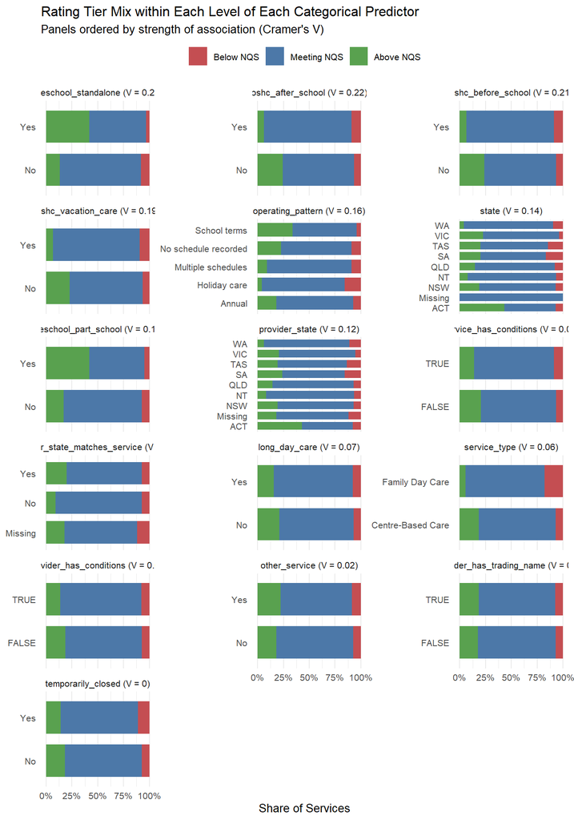

```r
categorical_outcome_plot
```

**Associations Between Predictors**

Multi-collinearity between categorical predictors were checked to further identify redundant features. The results is shown in the heatmap below:

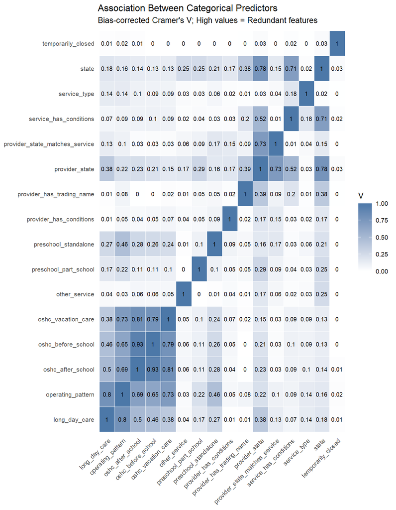

```r
categorical_pairwise_plot
```

Furthermore, high associations between the variable `state` with `provider_state`, `service_has_conditions` and between `provider_state` and `provider_state_matches_service` shows that these variables are somewhat correlated.

Overall, the graph showcased that certain categorical variables might be redundant. Some potential fixes might be to only include one representative variable per cluster, perform regularization on the cluster, or use tree-based models to avoid inflating variance.

**Standardised Residuals**

Further examinations of the seven categorical variables with the highest association with `rating_tier`, the following can be surmised:

- `operating_pattern`: Services with “School terms” schedule are over-represented in “Above NQS” (+25) and “Multiple schedules” are over-represented in “Meeting NQS”.
- Services that offers OSHC are over-represented in “Meeting NQS” (+17.8 to +21.9) but under-represented in “Above NQS” (-24.7 to -29.1).
- `preschool_part_school`: Services offering part school-based preschool or kindergarten is over-represented in “Above NQS” (+18.2) and under-represented in “Meeting NQS” (-14.3).
- `preschool_standalone`: Contains the largest residual of the seven variables, with a value of 36.7 for standalone schools with “Above NQS” rating. Both other rating tier values are under-represented.
- `state`: WA is over-represented in “Meeting NQS” and under-represented in “Above NQS”. VIC is under-represented in “Below NQS” and over-represented in “Above NQS”. SA is over-represented in “Below NQS” and under-represented in “Meeting NQS”. ACT is over-represented in “Above NQS” and under-represented in “Meeting NQS”.

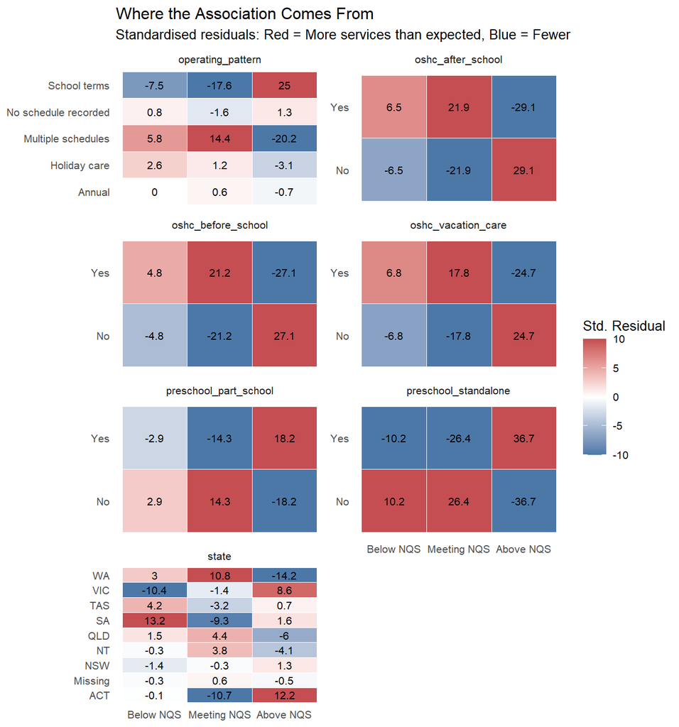

```r
categorical_residual_plot
```

# References

Australian Children’s Education & Care Quality Authority. (n.d.). *Assessment and rating process*. https://www.acecqa.gov.au/assessment/assessment-and-rating-process

Australian Children’s Education & Care Quality Authority. (n.d.). *National registers*. Retrieved September 18, 2026, from https://www.acecqa.gov.au/resources/national-registers

# AI Use Statement